# Model analysis

Seyyedeh Zeinab Mousavi

This document includes an account of model simulation, from its design and implementation to its analysis.

# Experiment design

Table 1 shows the model’s independent and dependent variables. Using the classification of variables in this table, we aim to investigate the plausibility of the proposed conceptualization in reproducing the discussed patterns in parenting-SC association (the PS-LGRD link) while also accounting for the joint effect of peer influence on adolescents’ SC development (PS-PIS-LGRD association).

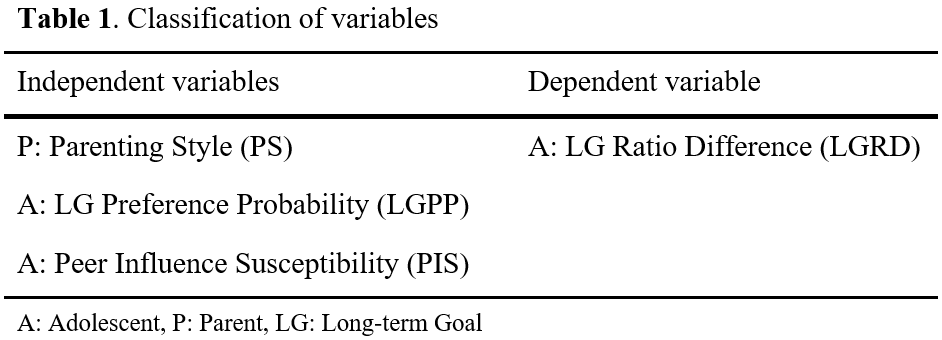

Table 2 presents a complete list of model parameters. To better analyze the desired outputs, we consider one of the adolescent agents as the target agent (TA) and the rest as peer agents (PAs). Note that all agents go through the same processes described in the article, albeit with different parameter configurations, which we will explain in the following paragraphs.

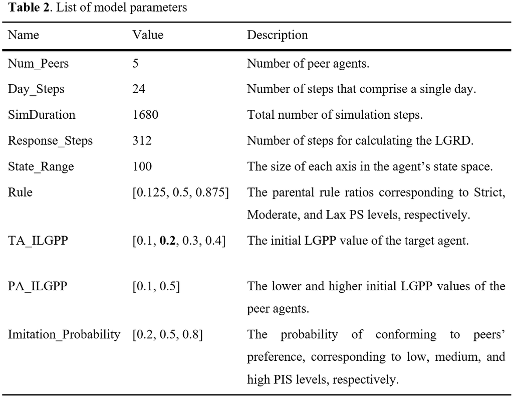

With the assumption of uniform imitation probabilities across all adolescent agents and two conditions for peers’ initial LGPP/SC (low or high), we end up with 54 possible combinations of the PS, the PIS, and the PA_LGPP variables (3 levels of TA parenting style × 3 levels of PA parenting style × 3 levels of PIS × 2 PA_ILGPP conditions = 54). It’s important to note that we have considered similar parenting styles for all peer family units.

The vector “Setup_Idx” in the main experiment code (*Run_Experiment.R*) contains the setup indices as specified in the file *Setup.xlsx*. The code calls the function *Experiment_Setup* which accesses this file to set the model configuration.

# Results

## Parents and SC development

The reader can reproduce the bar plot of LGRD vs. initial LGPP values presented in the article (Fig. 2) by running the code Fig_ILGPP_SF.R.

Moreover, the figure depicting the distribution of LGRD for different parenting styles (Fig. 3) is the result of running the code Fig_LGRDhist_SF.R.

Finally, we created the provided attractor plot (Fig. 4) using the code Fig_Attractors_SF.R.

## SC development among peers

Table 3 presents the results for the scenario where the target agent, with an initial LGPP of 0.2, is surrounded by peers with a lower initial LGPP of 0.1. In this experiment, the target and peer family units all have the same parenting style. The reader can obtain the provided confidence intervals for the relevant setup numbers by running the code ExpAnalysis_MultipleFU.R.

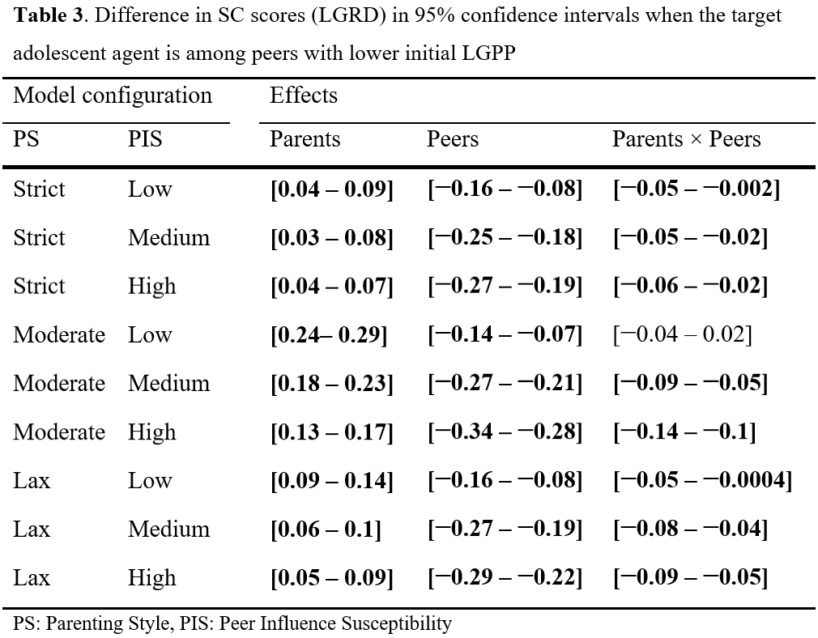

To plot the interaction effect between parental rules and peer influence on the target agent’s LGRD (Fig. 5), we use the code Fig_PaRxPeI.R. The left-hand plot in this figure depicts a negative peer influence from the lower peer self-control setup number 32. In this setup, the target and peer family units feature Moderate parenting styles. The right-hand plot, on the other hand, shows a positive peer influence from the higher peer self-control setup number 17. In this setup, the target family unit’s parenting style is set to Strict, and that of the peers to Moderate. In both cases, the peer influence susceptibility is set to High.

We used the code Fig_LGRDhist_MF.R to display the LGRD distribution of the same parameter setups mentioned above (Fig. 6).

To show an example of individual self-control score trajectories, we plot the LGRD values vs days (24 simulation steps) using the code Fig_TimeSeries_MF.R. Here the input are the same two setup numbers discussed earlier. The “subjects” are chosen randomly with the seed equal to 10 for setup number 32 (Fig. 7), and equal to 6 for setup number 17 (Fig. 8).